# Time Series Analysis on e-Commerce Data to Predict the Price of a Product in FUTURE

# Problem Description

Using e-commerce data, build time series models to predict the price of a certain product for next 4 months in advance. And finally evaluate each of the algorithms.

## Clear the Global Environment

```r
rm(list=ls(all=TRUE))
```

## Load required R library

```r
library(zoo) # Z's Ordered Observations
library(dplyr)
library(TTR) # Technical Trading Rules
library(forecast)
library(DMwR)
```

## Read Data from RData

- Set current working directory
- Use readRDS function to read RData file

```r
PATH = getwd()
setwd(PATH)
rm(PATH)

data = readRDS("Data.rds")
```

## Explore and understand the data

```r
## Dimension of the Data set
dim(data)
```

```
## [1] 19657     3
```

```r
str(data)
```

```
## Classes 'data.table' and 'data.frame':   19657 obs. of  3 variables:
##  $ SKU  : num  1 2 3 1 2 2 2 1 1 2 ...
##  $ Price: num  130 58 84.4 160 57 ...
##  $ Date : chr  "2009-06-01" "2009-06-01" "2009-12-08" "2009-12-08" ...
##  - attr(*, ".internal.selfref")=<externalptr>
```

```r
## Look at the summary statistics
summary(data)
```

```
##       SKU            Price            Date
##  Min.   :1.000   Min.   : 20.27   Length:19657
##  1st Qu.:1.000   1st Qu.: 50.15   Class :character
##  Median :2.000   Median : 70.97   Mode  :character
##  Mean   :1.942   Mean   : 80.63
##  3rd Qu.:3.000   3rd Qu.:105.00
##  Max.   :3.000   Max.   :999.00
```

## Look at the first and last 6 records using head and tail commands

```r
print(head(data, 6))
```

```
##   SKU  Price       Date
## 1   1 129.98 2009-06-01
## 2   2  57.96 2009-06-01
## 3   3  84.38 2009-12-08
## 4   1 159.96 2009-12-08
## 5   2  56.98 2009-12-08
## 6   2  58.38 2009-12-08
```

```r
print(tail(data, 6))
```

```
##       SKU Price       Date
## 19652   3 79.62 2013-08-09
## 19653   2 39.68 2013-08-09
## 19654   3 78.00 2013-08-09
## 19655   3 79.62 2013-08-09
## 19656   3 79.62 2013-08-09
## 19657   2 38.99 2013-08-09
```

```r
## Look into SKU attribute
table(data$SKU)
```

```
##
##    1    2    3
## 6997 6812 5848
```

## Convert attributes into appropriate type

```r
data$SKU = as.factor(data$SKU)
# data$Price = as.numeric(data$Price)
data$Date = as.Date(data$Date, format="%Y-%m-%d")
```

```r
# Summary of the data
summary(data)
```

```
##  SKU          Price             Date
##  1:6997   Min.   : 20.27   Min.   :2009-03-06
##  2:6812   1st Qu.: 50.15   1st Qu.:2010-10-22
##  3:5848   Median : 70.97   Median :2011-11-06
##           Mean   : 80.63   Mean   :2011-10-25
##           3rd Qu.:105.00   3rd Qu.:2012-11-26
##           Max.   :999.00   Max.   :2013-12-02
```

```r
# Re-look at the first 6 records
head(data)
```

```
##   SKU  Price       Date
## 1   1 129.98 2009-06-01
## 2   2  57.96 2009-06-01
## 3   3  84.38 2009-12-08
## 4   1 159.96 2009-12-08
## 5   2  56.98 2009-12-08
## 6   2  58.38 2009-12-08
```

## Focusing on a particular product of choice

- Since different products price vary in a different way along the year we choose a particular product.

```r
data = data[data$SKU==3,]
```

## Basic info about that product

```r
dim(data)
```

```
## [1] 5848    3
```

```r
summary(data)
```

```
##  SKU          Price             Date
##  1:   0   Min.   : 39.84   Min.   :2009-04-15
##  2:   0   1st Qu.: 60.00   1st Qu.:2011-01-26
##  3:5848   Median : 72.25   Median :2012-03-01
##           Mean   : 73.30   Mean   :2011-12-31
##           3rd Qu.: 83.75   3rd Qu.:2013-01-08
##           Max.   :999.00   Max.   :2013-12-02
```

```r
head(data)
```

```
##    SKU  Price       Date
## 3    3  84.38 2009-12-08
## 12   3 115.98 2009-06-01
## 23   3 115.98 2009-06-02
## 24   3  84.38 2009-12-09
## 36   3 115.98 2009-06-03
## 41   3  84.38 2009-12-10
```

## Sort the Data in increasing order of date

```r
data = data[order(data$Date, decreasing=F), ]

head(data)
```

```
##      SKU Price       Date
## 1984   3 58.65 2009-04-15
## 2006   3 79.64 2009-04-16
## 2009   3 58.65 2009-04-16
## 2021   3 79.64 2009-04-17
## 2031   3 58.65 2009-04-17
## 2045   3 79.64 2009-04-18
```

## As all records has same SKU, it can be removed

```r
data$SKU = NULL

head(data)
```

```
##      Price       Date
## 1984 58.65 2009-04-15
## 2006 79.64 2009-04-16
## 2009 58.65 2009-04-16
## 2021 79.64 2009-04-17
## 2031 58.65 2009-04-17
## 2045 79.64 2009-04-18
```

## Observation & Analysis

- On the given date, product has multiple prices, so one way is to consider the min price.
- Use dplyr package to do the same.

```r
library(dplyr)

data = data %>% group_by(Date) %>% summarise("MinPrice" = min(Price))

data = data.frame(data)

head(data)
```

```
##         Date MinPrice
## 1 2009-04-15    58.65
## 2 2009-04-16    58.65
## 3 2009-04-17    58.65
## 4 2009-04-18    79.64
## 5 2009-05-30   115.98
## 6 2009-05-31   115.98
```

## Handle missing values

- Some times there will be missing entries in dates, which will create a missing day/month/quarter/annual

## Detect missing values

- Using min and max date in the data, create new date field with continuous sequence of dates
- Check Data field in Data against newly created data field and find missing values.

```r
minDate = min(data$Date)
maxDate = max(data$Date)

minDate
```

```
## [1] "2009-04-15"
```

```r
maxDate
```

```
## [1] "2013-12-02"
```

```r
seq = data.frame("DateRange" = seq(minDate, maxDate, by="days"))

data = seq %>% full_join(data, c("DateRange" = "Date"))

data = data.frame(data)

rm(minDate, maxDate, seq)

head(data,10)
```

```
##     DateRange MinPrice
## 1  2009-04-15    58.65
## 2  2009-04-16    58.65
## 3  2009-04-17    58.65
## 4  2009-04-18    79.64
## 5  2009-04-19       NA
## 6  2009-04-20       NA
## 7  2009-04-21       NA
## 8  2009-04-22       NA
## 9  2009-04-23       NA
## 10 2009-04-24       NA
```

## Imputation of Missing Values

- Replace the missing values by taking average of it’s most recent preceding and succeeding values.
- For that, use na.locf (Last Observation Carried Forward) function in the “zoo” package and rev function

```r
data$MinPrice = (na.locf(data$MinPrice, fromLast = FALSE) +
                    na.locf(data$MinPrice, fromLast = TRUE))/2

head(data)
```

```
##    DateRange MinPrice
## 1 2009-04-15    58.65
## 2 2009-04-16    58.65
## 3 2009-04-17    58.65
## 4 2009-04-18    79.64
## 5 2009-04-19    97.81
## 6 2009-04-20    97.81
```

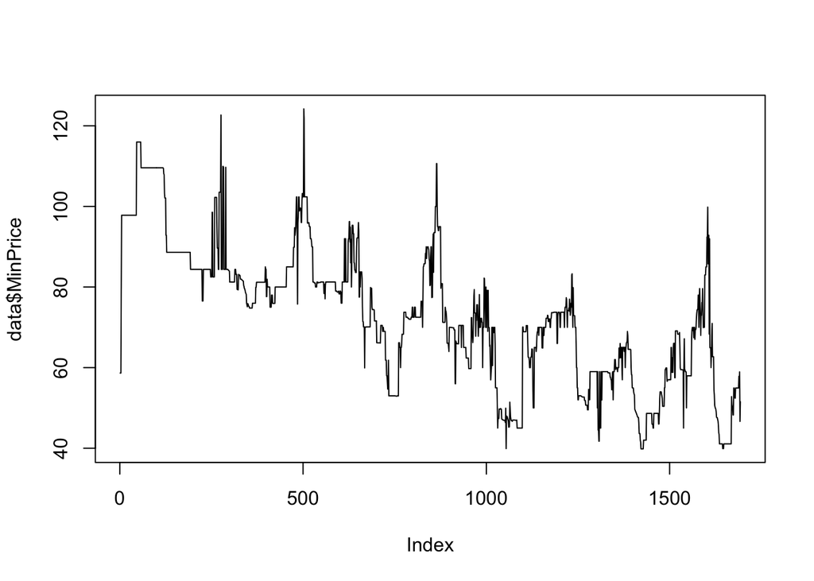

```r
plot(data$MinPrice, type = 'l')
```

## Observation on MinPrice

- As per domain expert requirement, aggregated the data at Month level by taking mean

```r
# Derive Year and Month attribute
data$Year = as.numeric(format(data$DateRange, format="%Y"))
data$Month = as.numeric(format(data$DateRange, format="%m"))


data = data %>% group_by(Year, Month) %>% summarise("MeanPrice" = mean(MinPrice))

print(data)
```

```
## # A tibble: 57 x 3
## # Groups:   Year [5]
##     Year Month MeanPrice
##    <dbl> <dbl>     <dbl>
##  1  2009     4      89.3
##  2  2009     5      99.0
##  3  2009     6     112.
##  4  2009     7     110.
##  5  2009     8      99.3
##  6  2009     9      88.6
##  7  2009    10      87.5
##  8  2009    11      83.6
##  9  2009    12      86.5
## 10  2010     1      94.6
## # … with 47 more rows
```

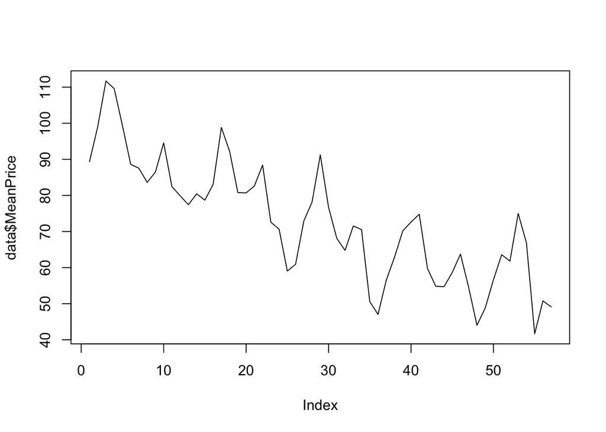

```r
data = data.frame(data)

plot(data$MeanPrice, type = 'l')
```

## Observation on MinPrice

```r
# Creating sequence Time variable.
data$Time = 1:nrow(data)

# Month attribute is used in future model for seasonality
data$Month = as.factor(data$Month)

# Year attribute is not required further, so removing it
data$Year = NULL

head(data)
```

```
##   Month MeanPrice Time
## 1     4  89.33187    1
## 2     5  98.98226    2
## 3     6 111.71333    3
## 4     7 109.58000    4
## 5     8  99.34645    5
## 6     9  88.61500    6
```

## View data

```r
# View(data)
```

## Splitting of the Dataset into Train and Test

- As this data set is time dependent and sequence is important i.e. no random split.

```r
train = data[1:53,]
test = data[54:nrow(data),]
rm(data)
```

## Regression on time

- As trend is also present Regression on time will work.

### Simple Linear Regression

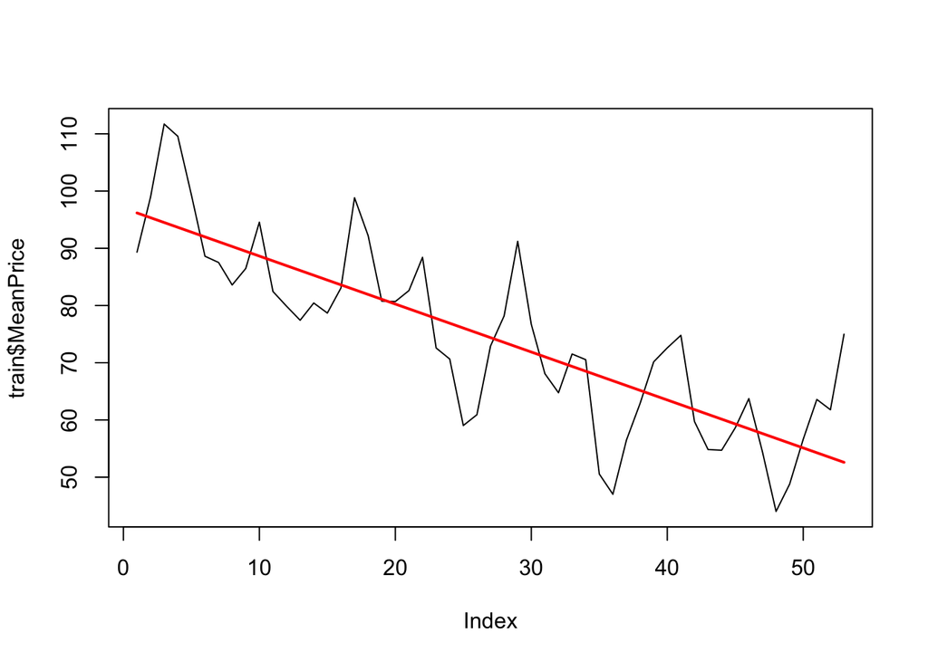

```r
## Simple linear regression
lm1 = lm(MeanPrice~Time, data = train)

pred_Train = predict(lm1)
pred_Test  = predict(lm1, test)

plot(train$MeanPrice, type="l")
points(train$Time, pred_Train, type="l", col="red", lwd=2)
```

### Find error for lm1 on both Test and Train data

```r
lm1TrainError = regr.eval(train$MeanPrice, pred_Train)
lm1TestError  = regr.eval(test$MeanPrice, pred_Test)
lm1TrainError
```

```
##        mae        mse       rmse       mape
##  7.3604306 84.4599186  9.1902078  0.1050726
```

```r
lm1TestError
```

```
##        mae        mse       rmse       mape
##  6.2980475 78.4718183  8.8584320  0.1161648
```

### Linear Regression (Quadratic)

```r
lm2 = lm(MeanPrice~poly(train$Time, 2, raw=TRUE), data = train)


pred_Train = predict(lm2)
pred_Test  = predict(lm2, test)
```

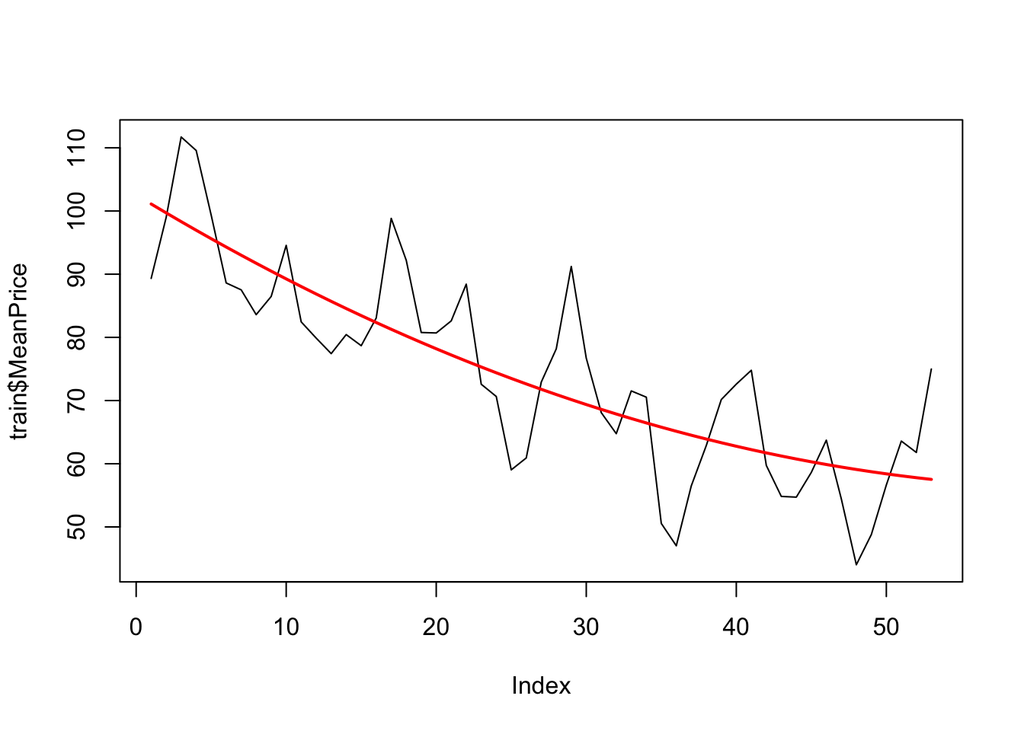

```r
plot(train$MeanPrice, type="l")
points(train$Time, pred_Train, type="l", col="red", lwd=2)
```

### Find error for lm2 on both Test and Train data

```r
lm2TrainError = regr.eval(train$MeanPrice, pred_Train)
lm2TestError  = regr.eval(test$MeanPrice, pred_Test)
lm2TrainError
```

```
##        mae        mse       rmse       mape
##  7.2520165 79.0233764  8.8895093  0.1031797
```

```r
lm2TestError
```

```
##         mae         mse        rmse        mape
##  307.137920 9821.103920   99.101483    6.367266
```

### Seasonal Linear Regression Model using dummies (i.e. Month factor attribute is used to capture seasonality)

```r
str(train)
```

```
## 'data.frame':    53 obs. of  3 variables:
##  $ Month    : Factor w/ 12 levels "1","2","3","4",..: 4 5 6 7 8 9 10 11 12 1 ...
##  $ MeanPrice: num  89.3 99 111.7 109.6 99.3 ...
##  $ Time     : int  1 2 3 4 5 6 7 8 9 10 ...
```

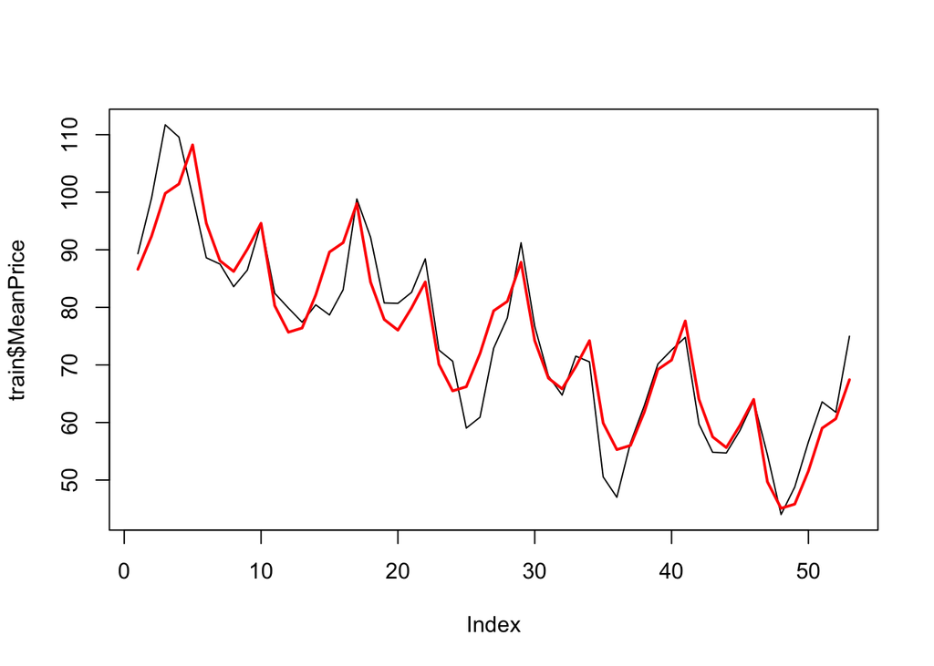

```r
slm1 <- lm(MeanPrice~., data=train)

pred_Train = predict(slm1)
pred_Test  = predict(slm1, test)

plot(train$MeanPrice, type="l")
points(train$Time, pred_Train, type="l", col="red", lwd=2)
```

### Find error for slm1 on both Test and Train data

```r
slm1TrainError = regr.eval(train$MeanPrice, pred_Train)
slm1TestError = regr.eval(test$MeanPrice, pred_Test)
slm1TrainError
```

```
##         mae         mse        rmse        mape
##  3.98447730 25.44172377  5.04397896  0.05487652
```

```r
slm1TestError
```

```
##        mae        mse       rmse       mape
##  6.0566694 57.5215150  7.5842940  0.1099742
```

### Seasonal Linear Regression Model using dummies (i.e. Month factor attribute is used to capture seasonality) along with transformation

```r
str(train)
```

```
## 'data.frame':    53 obs. of  3 variables:
##  $ Month    : Factor w/ 12 levels "1","2","3","4",..: 4 5 6 7 8 9 10 11 12 1 ...
##  $ MeanPrice: num  89.3 99 111.7 109.6 99.3 ...
##  $ Time     : int  1 2 3 4 5 6 7 8 9 10 ...
```

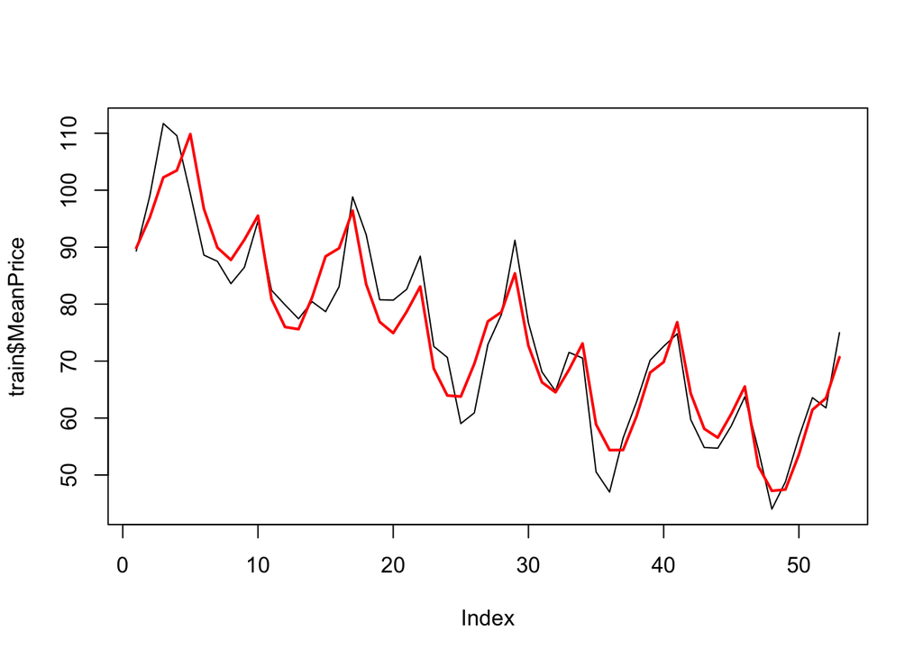

```r
slm2 <- lm(MeanPrice~poly(Time, 2, raw=TRUE)+Month, data=train)

pred_Train = predict(slm2)
pred_Test  = predict(slm2, test)

plot(train$MeanPrice, type="l")
points(train$Time, pred_Train, type="l", col="red", lwd=2)
```

```r
slm2TrainError = regr.eval(train$MeanPrice, pred_Train)
slm2TestError = regr.eval(test$MeanPrice, pred_Test)
slm2TrainError
```

```
##         mae         mse        rmse        mape
##  3.97814991 22.50621737  4.74407181  0.05450343
```

```r
slm2TestError
```

```
##        mae        mse       rmse       mape
##  6.4363318 56.6119027  7.5240882  0.1293625
```

### Converting data into R time series object

- Our target variable is price and price is aggregated at month level

```r
train_TS <- ts(train$MeanPrice, frequency = 12, start = c(2009, 4))
train_TS
```

```
##            Jan       Feb       Mar       Apr       May       Jun       Jul
## 2009                                89.33187  98.98226 111.71333 109.58000
## 2010  94.56161  82.45250  79.88065  77.42767  80.44161  78.68367  83.06452
## 2011  88.42161  72.58196  70.64968  59.03067  60.91677  72.91667  78.18194
## 2012  70.53839  50.55517  47.01290  56.50133  62.88645  70.15700  72.60000
## 2013  63.73032  54.42857  44.01097  48.79200  56.64129  63.58633  61.78355
##            Aug       Sep       Oct       Nov       Dec
## 2009  99.34645  88.61500  87.52210  83.59500  86.47677
## 2010  98.83145  92.20900  80.77274  80.69867  82.61000
## 2011  91.21645  76.70200  68.08935  64.75600  71.52661
## 2012  74.79161  59.73300  54.82694  54.71333  58.62968
## 2013  74.99113
```

```r
test_TS <- ts(test$MeanPrice, frequency = 12, start = c(2013, 9))
test_TS
```

```
##           Sep      Oct      Nov      Dec
## 2013 66.84800 41.66387 50.78450 49.10000
```

### Visualize the time series Data

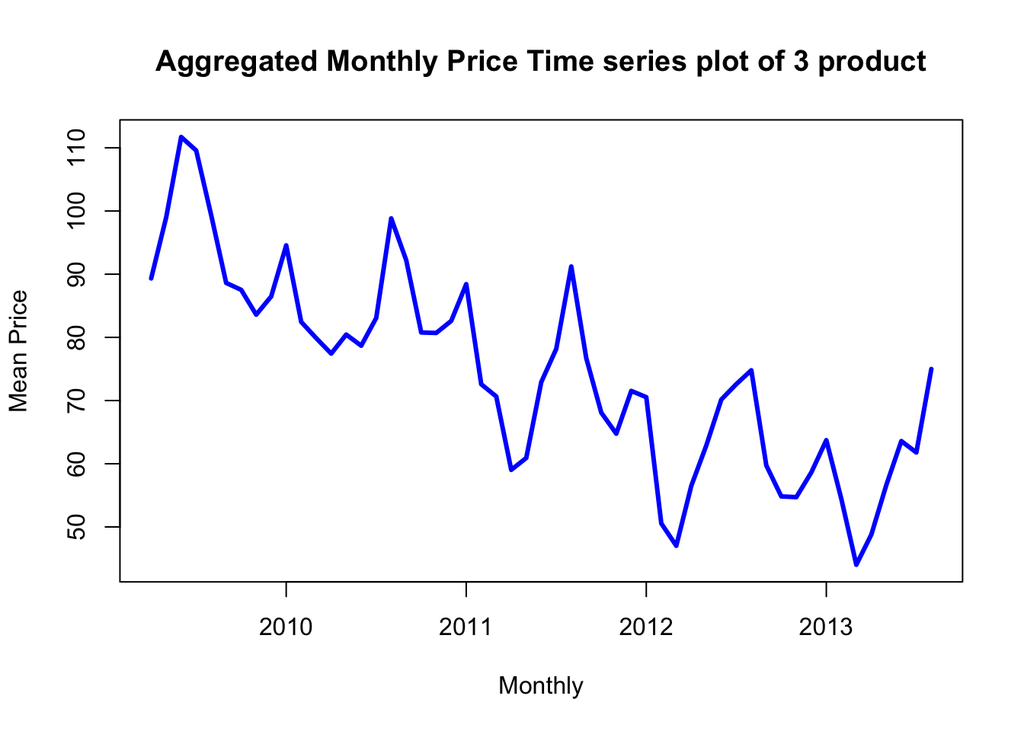

```r
plot(train_TS,
     type="l", lwd=3, col="blue",
     xlab="Monthly", ylab="Mean Price",
     main="Aggregated Monthly Price Time series plot of 3 product")
```

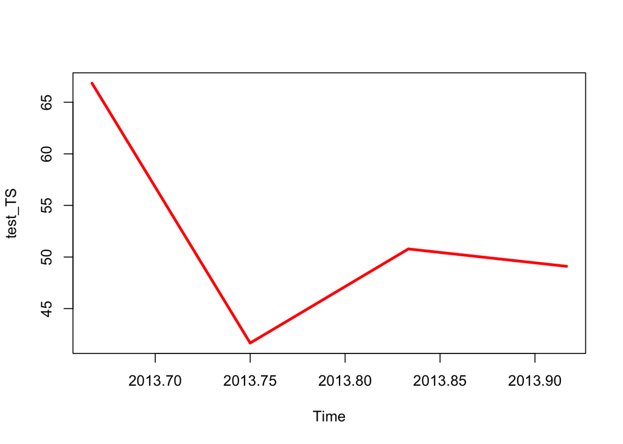

```r
plot(test_TS, col="red", lwd=3)
```

### Decomposed Time Series

- Decompose will provide more information on seasonality, trend and randomness

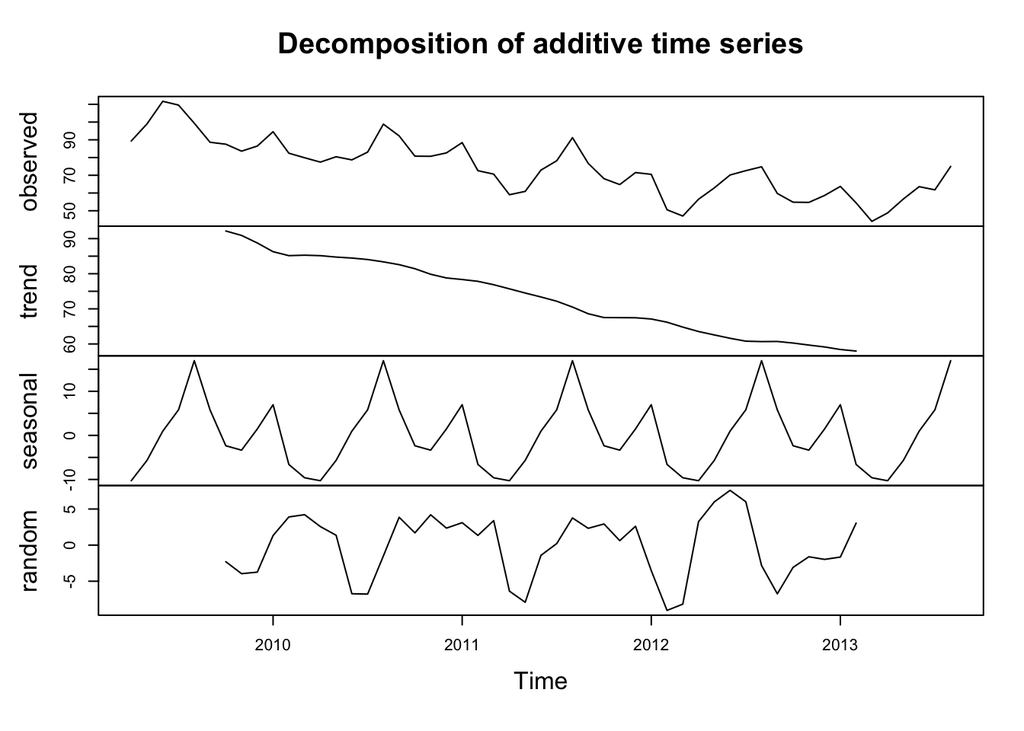

```r
train_Decomposed = decompose(train_TS)
plot(train_Decomposed)
```

```r
rm(train_Decomposed)
```

### Modelling the time series using simple moving averages

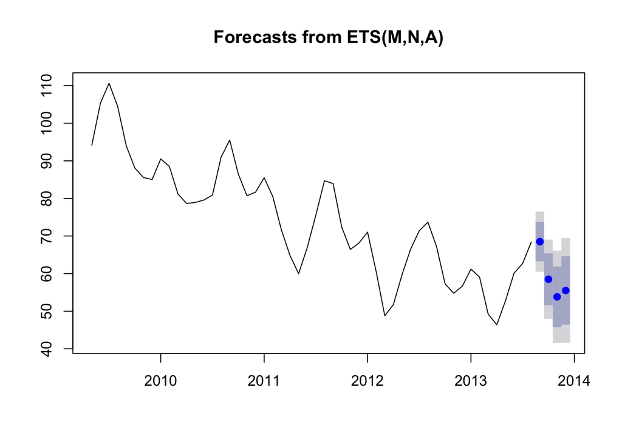

```r
fitsma = SMA(train_TS, n=2)
predsma = forecast(fitsma, h=4)
plot(predsma)
```

```r
train_TS
```

```
##            Jan       Feb       Mar       Apr       May       Jun       Jul
## 2009                                89.33187  98.98226 111.71333 109.58000
## 2010  94.56161  82.45250  79.88065  77.42767  80.44161  78.68367  83.06452
## 2011  88.42161  72.58196  70.64968  59.03067  60.91677  72.91667  78.18194
## 2012  70.53839  50.55517  47.01290  56.50133  62.88645  70.15700  72.60000
## 2013  63.73032  54.42857  44.01097  48.79200  56.64129  63.58633  61.78355
##            Aug       Sep       Oct       Nov       Dec
## 2009  99.34645  88.61500  87.52210  83.59500  86.47677
## 2010  98.83145  92.20900  80.77274  80.69867  82.61000
## 2011  91.21645  76.70200  68.08935  64.75600  71.52661
## 2012  74.79161  59.73300  54.82694  54.71333  58.62968
## 2013  74.99113
```

```r
fitsma
```

```
##            Jan       Feb       Mar       Apr       May       Jun       Jul
## 2009                                      NA  94.15707 105.34780 110.64667
## 2010  90.51919  88.50706  81.16657  78.65416  78.93464  79.56264  80.87409
## 2011  85.51581  80.50179  71.61582  64.84017  59.97372  66.91672  75.54930
## 2012  71.03250  60.54678  48.78404  51.75712  59.69389  66.52173  71.37850
## 2013  61.18000  59.07945  49.21977  46.40148  52.71665  60.11381  62.68494
##            Aug       Sep       Oct       Nov       Dec
## 2009 104.46323  93.98073  88.06855  85.55855  85.03589
## 2010  90.94798  95.52023  86.49087  80.73570  81.65433
## 2011  84.69919  83.95923  72.39568  66.42268  68.14131
## 2012  73.69581  67.26231  57.27997  54.77013  56.67151
## 2013  68.38734
```

```r
predsma$mean
```

```
##           Sep      Oct      Nov      Dec
## 2013 68.49939 58.49201 53.81743 55.50964
```

```r
predsma
```

```
##          Point Forecast    Lo 80    Hi 80    Lo 95    Hi 95
## Sep 2013       68.49939 63.26228 73.73649 60.48993 76.50884
## Oct 2013       58.49201 51.60256 65.38147 47.95550 69.02852
## Nov 2013       53.81743 45.78498 61.84987 41.53286 66.10199
## Dec 2013       55.50964 46.41435 64.60494 41.59959 69.41970
```

### Find error for SMA on both Test and Train data

```r
smaTrainError = regr.eval(train_TS[2:length(train_TS)], fitsma[2:length(train_TS)])
smaTestError = regr.eval(test$MeanPrice, predsma$mean)
smaTrainError
```

```
##         mae         mse        rmse        mape
##  3.46034932 17.80178616  4.21921630  0.04903119
```

```r
smaTestError
```

```
##        mae        mse       rmse       mape
##  6.9805242 84.0488976  9.1678186  0.1547176
```

### Weighted Moving Averages

```r
fitwma = WMA(train_TS, n=2, 1:2)
predwma = forecast(fitwma, h=4)
```

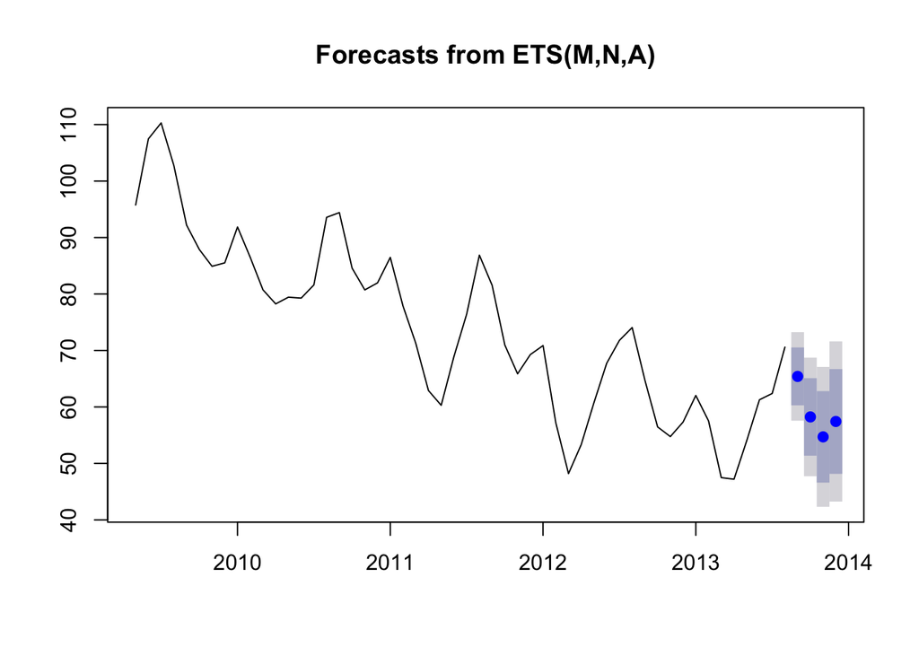

```r
plot(predwma)
```

```r
train_TS
```

```
##            Jan       Feb       Mar       Apr       May       Jun       Jul
## 2009                                89.33187  98.98226 111.71333 109.58000
## 2010  94.56161  82.45250  79.88065  77.42767  80.44161  78.68367  83.06452
## 2011  88.42161  72.58196  70.64968  59.03067  60.91677  72.91667  78.18194
## 2012  70.53839  50.55517  47.01290  56.50133  62.88645  70.15700  72.60000
## 2013  63.73032  54.42857  44.01097  48.79200  56.64129  63.58633  61.78355
##            Aug       Sep       Oct       Nov       Dec
## 2009  99.34645  88.61500  87.52210  83.59500  86.47677
## 2010  98.83145  92.20900  80.77274  80.69867  82.61000
## 2011  91.21645  76.70200  68.08935  64.75600  71.52661
## 2012  74.79161  59.73300  54.82694  54.71333  58.62968
## 2013  74.99113
```

```r
fitwma
```

```
##            Jan       Feb       Mar       Apr       May       Jun       Jul
## 2009                                      NA  95.76546 107.46964 110.29111
## 2010  91.86667  86.48887  80.73793  78.24533  79.43696  79.26965  81.60423
## 2011  86.48441  77.86185  71.29377  62.90367  60.28807  68.91670  76.42685
## 2012  70.86780  57.21624  48.19366  53.33852  60.75808  67.73348  71.78567
## 2013  62.03011  57.52916  47.48350  47.19832  54.02486  61.27132  62.38448
##            Aug       Sep       Oct       Nov       Dec
## 2009 102.75763  92.19215  87.88640  84.90403  85.51618
## 2010  93.57581  94.41648  84.58483  80.72336  81.97289
## 2011  86.87161  81.54015  70.96024  65.86712  69.26974
## 2012  74.06108  64.75254  56.46229  54.75120  57.32423
## 2013  70.58860
```

```r
predwma
```

```
##          Point Forecast    Lo 80    Hi 80    Lo 95    Hi 95
## Sep 2013       65.40473 60.28105 70.52841 57.56874 73.24072
## Oct 2013       58.23234 51.36935 65.09534 47.73629 68.72839
## Nov 2013       54.69943 46.60061 62.79825 42.31335 67.08551
## Dec 2013       57.42639 48.15104 66.70174 43.24097 71.61181
```

### Find error for WMA on both Test and Train data

```r
wmaTrainError = regr.eval(train_TS[2:length(train_TS)], fitwma[2:length(train_TS)])
wmaTestError = regr.eval(test$MeanPrice, predwma$mean)
wmaTrainError
```

```
##        mae        mse       rmse       mape
## 2.30689955 7.91190496 2.81281086 0.03268746
```

```r
wmaTestError
```

```
##        mae        mse       rmse       mape
##  7.5632654 90.3131941  9.5033254  0.1664824
```

### Exponential Moving Averages

```r
fitEma = EMA(train_TS, n=2)
predema = forecast(fitEma, h=4)
```

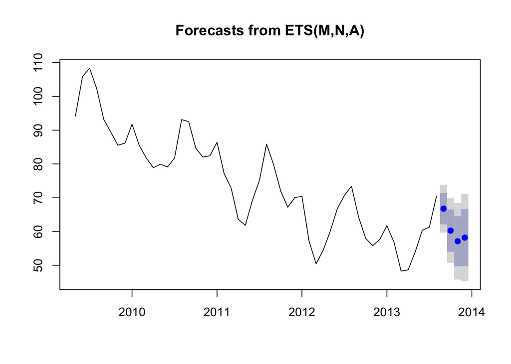

```r
plot(predema)
```

```r
train_TS
```

```
##            Jan       Feb       Mar       Apr       May       Jun       Jul
## 2009                                89.33187  98.98226 111.71333 109.58000
## 2010  94.56161  82.45250  79.88065  77.42767  80.44161  78.68367  83.06452
## 2011  88.42161  72.58196  70.64968  59.03067  60.91677  72.91667  78.18194
## 2012  70.53839  50.55517  47.01290  56.50133  62.88645  70.15700  72.60000
## 2013  63.73032  54.42857  44.01097  48.79200  56.64129  63.58633  61.78355
##            Aug       Sep       Oct       Nov       Dec
## 2009  99.34645  88.61500  87.52210  83.59500  86.47677
## 2010  98.83145  92.20900  80.77274  80.69867  82.61000
## 2011  91.21645  76.70200  68.08935  64.75600  71.52661
## 2012  74.79161  59.73300  54.82694  54.71333  58.62968
## 2013  74.99113
```

```r
fitEma
```

```
##            Jan       Feb       Mar       Apr       May       Jun       Jul
## 2009                                      NA  94.15707 105.86124 108.34041
## 2010  91.76191  85.55564  81.77231  78.87588  79.91970  79.09568  81.74157
## 2011  86.41978  77.19457  72.83131  63.63088  61.82148  69.21827  75.19405
## 2012  70.38304  57.16446  50.39676  54.46647  60.07979  66.79793  70.66598
## 2013  61.71604  56.85773  48.29322  48.62574  53.96944  60.38070  61.31593
##            Aug       Sep       Oct       Nov       Dec
## 2009 102.34444  93.19148  89.41189  85.53396  86.16250
## 2010  93.13482  92.51761  84.68770  82.02834  82.41611
## 2011  85.87565  79.75988  71.97953  67.16384  70.07236
## 2012  73.41640  64.29413  57.98267  55.80311  57.68749
## 2013  70.43273
```

```r
predema
```

```
##          Point Forecast    Lo 80    Hi 80    Lo 95    Hi 95
## Sep 2013       66.76705 62.13062 71.40349 59.67623 73.85788
## Oct 2013       60.26537 54.01556 66.51517 50.70712 69.82362
## Nov 2013       57.09858 49.69012 64.50705 45.76832 68.42885
## Dec 2013       58.19706 49.74905 66.64507 45.27694 71.11717
```

### Find error for EMA on both Test and Train data

```r
emaTrainError = regr.eval(train_TS[2:length(train_TS)], fitEma[2:length(train_TS)])
emaTestError = regr.eval(test$MeanPrice, predema$mean)
emaTrainError
```

```
##       mae       mse      rmse      mape
## 2.5945869 9.4357116 3.0717603 0.0367568
```

```r
emaTestError
```

```
##         mae         mse        rmse        mape
##   8.5233956 117.1615797  10.8241203   0.1893209
```

## HoltWinters model

### Build a HoltWinters model

```r
model_HW = HoltWinters(train_TS)
model_HW
```

```
## Holt-Winters exponential smoothing with trend and additive seasonal component.
##
## Call:
## HoltWinters(x = train_TS)
##
## Smoothing parameters:
##  alpha: 0.3727269
##  beta : 0
##  gamma: 0.9621566
##
## Coefficients:
##            [,1]
## a    59.0621049
## b    -0.7574812
## s1    0.4333145
## s2   -3.2103581
## s3   -3.2258040
## s4    1.5402385
## s5    5.9109799
## s6   -6.2013614
## s7  -13.9490602
## s8   -7.7330547
## s9   -0.7721952
## s10   5.3719761
## s11   4.6497546
## s12  15.7588265
```

### HoltWinters model - additive and multiplicative models

```r
# Additive Model
model_HW_Add = HoltWinters(train_TS, seasonal="additive")
model_HW_Add
```

```
## Holt-Winters exponential smoothing with trend and additive seasonal component.
##
## Call:
## HoltWinters(x = train_TS, seasonal = "additive")
##
## Smoothing parameters:
##  alpha: 0.3727269
##  beta : 0
##  gamma: 0.9621566
##
## Coefficients:
##            [,1]
## a    59.0621049
## b    -0.7574812
## s1    0.4333145
## s2   -3.2103581
## s3   -3.2258040
## s4    1.5402385
## s5    5.9109799
## s6   -6.2013614
## s7  -13.9490602
## s8   -7.7330547
## s9   -0.7721952
## s10   5.3719761
## s11   4.6497546
## s12  15.7588265
```

```r
# Multiplicative Model
model_HW_Mul = HoltWinters(train_TS, seasonal="multiplicative")
model_HW_Mul
```

```
## Holt-Winters exponential smoothing with trend and multiplicative seasonal component.
##
## Call:
## HoltWinters(x = train_TS, seasonal = "multiplicative")
##
## Smoothing parameters:
##  alpha: 0.2779267
##  beta : 0
##  gamma: 1
##
## Coefficients:
##           [,1]
## a   57.9395541
## b   -0.7574812
## s1   0.9723331
## s2   0.9184295
## s3   0.9300823
## s4   1.0152012
## s5   1.0958529
## s6   0.8997258
## s7   0.7500481
## s8   0.8593478
## s9   0.9990235
## s10  1.1160901
## s11  1.0987044
## s12  1.2942994
```

- Since you are building the models on monthly data, you will get 12 seasonal components. If you are reading the weekly data, you will get 53 seasonal components

### Prediction on the Train

```r
pred_train_HW = data.frame(model_HW_Mul$fitted)
pred_train_HW
```

```
##        xhat    level      trend    season
## 1  82.57879 90.99995 -0.7574812 0.9150767
## 2  83.98215 88.67797 -0.7574812 0.9552056
## 3  80.74508 86.89034 -0.7574812 0.9374481
## 4  84.30240 85.52171 -0.7574812 0.9945516
## 5  99.79067 84.41830 -0.7574812 1.1928006
## 6  92.89900 83.43732 -0.7574812 1.1235992
## 7  78.11477 82.50916 -0.7574812 0.9555127
## 8  75.66537 82.52480 -0.7574812 0.9253742
## 9  80.90820 83.27901 -0.7574812 0.9804496
## 10 90.71321 83.00394 -0.7574812 1.1029437
## 11 78.84231 81.66901 -0.7574812 0.9744262
## 12 73.87104 79.12594 -0.7574812 0.9426118
## 13 66.93540 77.41865 -0.7574812 0.8731330
## 14 67.94095 74.14502 -0.7574812 0.9257832
```

[output cut: 27 more lines]

```r
pred_train_HW$xhat
```

```
##  [1] 82.57879 83.98215 80.74508 84.30240 99.79067 92.89900 78.11477 75.66537
##  [9] 80.90820 90.71321 78.84231 73.87104 66.93540 67.94095 64.88269 71.03308
## [17] 87.00448 82.34560 70.00388 68.04546 68.19508 74.37286 61.41424 57.40384
## [25] 46.95832 52.60696 64.11317 68.54633 80.10863 67.29204 58.20525 55.09198
## [33] 59.80463 59.37611 45.58172 47.01135 52.51810 54.28373 59.62383 61.71176
## [41] 64.65824
```

### Prediction on test data

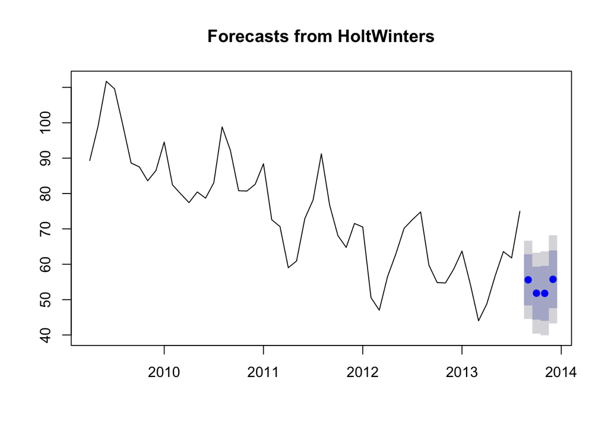

```r
pred_test_HW = forecast(model_HW_Mul, h = 4)

plot(pred_test_HW)
```

```r
pred_test_HW
```

```
##          Point Forecast    Lo 80    Hi 80    Lo 95    Hi 95
## Sep 2013       55.60002 48.36780 62.83225 44.53929 66.66076
## Oct 2013       51.82201 44.34473 59.29929 40.38649 63.25753
## Nov 2013       51.77499 44.01966 59.53033 39.91423 63.63575
## Dec 2013       55.74432 47.59205 63.89659 43.27651 68.21213
```

```r
pred_test_HW$mean
```

```
##           Sep      Oct      Nov      Dec
## 2013 55.60002 51.82201 51.77499 55.74432
```

### Error metrics

```r
# accuracy() from Forecast package
regr.eval(test$MeanPrice, pred_test_HW$mean)
```

```
##        mae        mse       rmse       mape
##  7.2602315 68.7081957  8.2890407  0.1417249
```

## Build a HoltWinters model with no trend and no seasonality

```r
hw_NT_NS = HoltWinters(train_TS, beta=F, gamma=F)
hw_NT_NS
```

```
## Holt-Winters exponential smoothing without trend and without seasonal component.
##
## Call:
## HoltWinters(x = train_TS, beta = F, gamma = F)
##
## Smoothing parameters:
##  alpha: 0.9999339
##  beta : FALSE
##  gamma: FALSE
##
## Coefficients:
##       [,1]
## a 74.99026
```

```r
train_TS
```

```
##            Jan       Feb       Mar       Apr       May       Jun       Jul
## 2009                                89.33187  98.98226 111.71333 109.58000
## 2010  94.56161  82.45250  79.88065  77.42767  80.44161  78.68367  83.06452
## 2011  88.42161  72.58196  70.64968  59.03067  60.91677  72.91667  78.18194
## 2012  70.53839  50.55517  47.01290  56.50133  62.88645  70.15700  72.60000
## 2013  63.73032  54.42857  44.01097  48.79200  56.64129  63.58633  61.78355
##            Aug       Sep       Oct       Nov       Dec
## 2009  99.34645  88.61500  87.52210  83.59500  86.47677
## 2010  98.83145  92.20900  80.77274  80.69867  82.61000
## 2011  91.21645  76.70200  68.08935  64.75600  71.52661
## 2012  74.79161  59.73300  54.82694  54.71333  58.62968
## 2013  74.99113
```

```r
head(hw_NT_NS$fitted)
```

```
##               xhat     level
## May 2009  89.33187  89.33187
## Jun 2009  98.98162  98.98162
## Jul 2009 111.71249 111.71249
## Aug 2009 109.58014 109.58014
## Sep 2009  99.34713  99.34713
## Oct 2009  88.61571  88.61571
```

```r
predhw_NT_NS = predict(hw_NT_NS, 4, prediction.interval = TRUE)
predhw_NT_NS
```

```
##               fit       upr      lwr
## Sep 2013 74.99026  91.68188 58.29863
## Oct 2013 74.99026  98.59500 51.38551
## Nov 2013 74.99026 103.89973 46.08078
## Dec 2013 74.99026 108.37186 41.60866
```

```r
forecast(model_HW_Mul, h = 4)
```

```
##          Point Forecast    Lo 80    Hi 80    Lo 95    Hi 95
## Sep 2013       55.60002 48.36780 62.83225 44.53929 66.66076
## Oct 2013       51.82201 44.34473 59.29929 40.38649 63.25753
## Nov 2013       51.77499 44.01966 59.53033 39.91423 63.63575
## Dec 2013       55.74432 47.59205 63.89659 43.27651 68.21213
```

### Find error for hw_NT_NS on both Test and Train data

```r
regr.eval(train$MeanPrice[2:length(train$MeanPrice)], hw_NT_NS$fitted[,1])
```

```
##         mae         mse        rmse        mape
##  6.92083808 71.20856584  8.43851680  0.09806457
```

```r
regr.eval(test$MeanPrice, predhw_NT_NS[,1])
```

```
##         mae         mse        rmse        mape
##  22.8911632 608.2920595  24.6635776   0.4814056
```

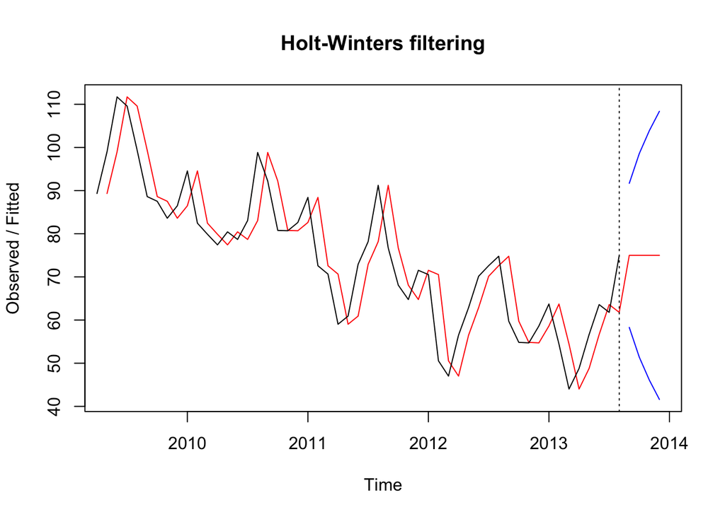

```r
plot(hw_NT_NS, predhw_NT_NS)
```

## Build a HoltWinters model with trend and no seasonality

```r
hw_T_NS = HoltWinters(train_TS, beta=T, gamma=F)
hw_T_NS
```

```
## Holt-Winters exponential smoothing with trend and without seasonal component.
##
## Call:
## HoltWinters(x = train_TS, beta = T, gamma = F)
##
## Smoothing parameters:
##  alpha: 0.9251175
##  beta : TRUE
##  gamma: FALSE
##
## Coefficients:
##       [,1]
## a 73.96515
## b 11.48082
```

```r
train_TS
```

```
##            Jan       Feb       Mar       Apr       May       Jun       Jul
## 2009                                89.33187  98.98226 111.71333 109.58000
## 2010  94.56161  82.45250  79.88065  77.42767  80.44161  78.68367  83.06452
## 2011  88.42161  72.58196  70.64968  59.03067  60.91677  72.91667  78.18194
## 2012  70.53839  50.55517  47.01290  56.50133  62.88645  70.15700  72.60000
## 2013  63.73032  54.42857  44.01097  48.79200  56.64129  63.58633  61.78355
##            Aug       Sep       Oct       Nov       Dec
## 2009  99.34645  88.61500  87.52210  83.59500  86.47677
## 2010  98.83145  92.20900  80.77274  80.69867  82.61000
## 2011  91.21645  76.70200  68.08935  64.75600  71.52661
## 2012  74.79161  59.73300  54.82694  54.71333  58.62968
## 2013  74.99113
```

```r
head(hw_T_NS$fitted)
```

```
##               xhat     level       trend
## Jun 2009 108.63264  98.98226   9.6503831
## Jul 2009 123.98303 111.48264  12.5003855
## Aug 2009 109.83442 110.65853  -0.8241093
## Sep 2009  89.60510 100.13182 -10.5267174
## Oct 2009  77.24647  88.68914 -11.4426757
## Nov 2009  84.81612  86.75263  -1.9365088
```

```r
predhw_T_NS = predict(hw_T_NS, 4, prediction.interval = TRUE)
head(predhw_T_NS)
```

```
##                fit      upr      lwr
## Sep 2013  85.44596 106.6780 64.21397
## Oct 2013  96.92678 141.5815 52.27205
## Nov 2013 108.40759 182.3424 34.47282
## Dec 2013 119.88841 227.7742 12.00263
```

### Find error for hw_T_NS on both Test and Train data

```r
regr.eval(train$MeanPrice[3:length(train$MeanPrice)], hw_T_NS$fitted[,1])
```

```
##         mae         mse        rmse        mape
##   8.7325086 115.0511689  10.7261908   0.1263981
```

```r
regr.eval(test$MeanPrice, predhw_T_NS[,1])
```

```
##         mae         mse        rmse        mape
##   50.568094 2932.823290   54.155547    1.045247
```

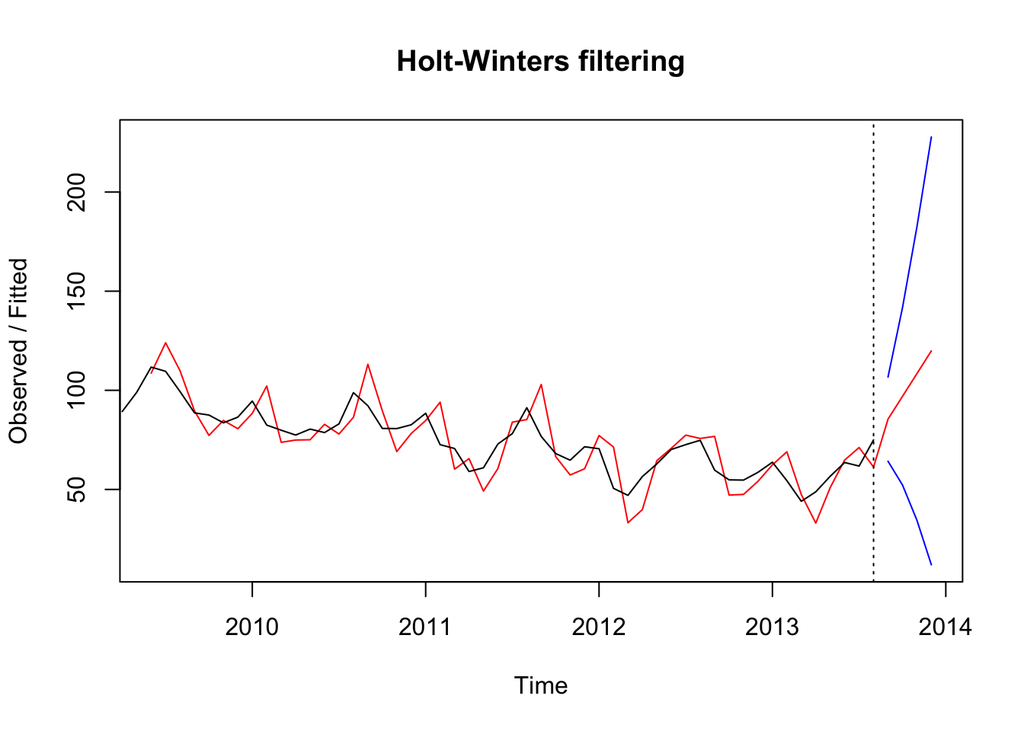

```r
plot(hw_T_NS, predhw_T_NS)
```

## HoltWinters model with trend and Seasonality

```r
hw_T_S = HoltWinters(train_TS, beta=T, gamma=T)
hw_T_S = HoltWinters(train_TS)
hw_T_S
```

```
## Holt-Winters exponential smoothing with trend and additive seasonal component.
##
## Call:
## HoltWinters(x = train_TS)
##
## Smoothing parameters:
##  alpha: 0.3727269
##  beta : 0
##  gamma: 0.9621566
##
## Coefficients:
##            [,1]
## a    59.0621049
## b    -0.7574812
## s1    0.4333145
## s2   -3.2103581
## s3   -3.2258040
## s4    1.5402385
## s5    5.9109799
## s6   -6.2013614
## s7  -13.9490602
## s8   -7.7330547
## s9   -0.7721952
## s10   5.3719761
## s11   4.6497546
## s12  15.7588265
```

```r
head(train_TS)
```

```
##            Apr       May       Jun       Jul       Aug       Sep
## 2009  89.33187  98.98226 111.71333 109.58000  99.34645  88.61500
```

```r
head(hw_T_S$fitted)
```

```
##              xhat    level      trend     season
## Apr 2010 83.16992 90.99995 -0.7574812 -7.0725445
## May 2010 83.68800 88.10218 -0.7574812 -3.6566946
## Jun 2010 80.24435 86.13468 -0.7574812 -5.1328446
## Jul 2010 83.70296 84.79549 -0.7574812 -0.3350463
## Aug 2010 99.14155 83.80004 -0.7574812 16.0989949
## Sep 2010 92.44193 82.92698 -0.7574812 10.2724392
```

```r
predhw_T_S = predict(hw_T_S, 4, prediction.interval = TRUE)
head(predhw_T_S)
```

```
##               fit      upr      lwr
## Sep 2013 58.73794 69.98481 47.49107
## Oct 2013 54.33678 66.33950 42.33407
## Nov 2013 53.56386 66.27755 40.85016
## Dec 2013 57.57242 70.95939 44.18545
```

### Find error for hw_T_S on both Test and Train data

```r
regr.eval(train$MeanPrice[13:length(train$MeanPrice)], hw_T_S$fitted[,1])
```

```
##         mae         mse        rmse        mape
##  4.60674466 32.12834186  5.66818682  0.07209383
```

```r
regr.eval(test$MeanPrice, predhw_T_S[,1])
```

```
##        mae        mse       rmse       mape
##  8.0086879 76.4706369  8.7447491  0.1631935
```

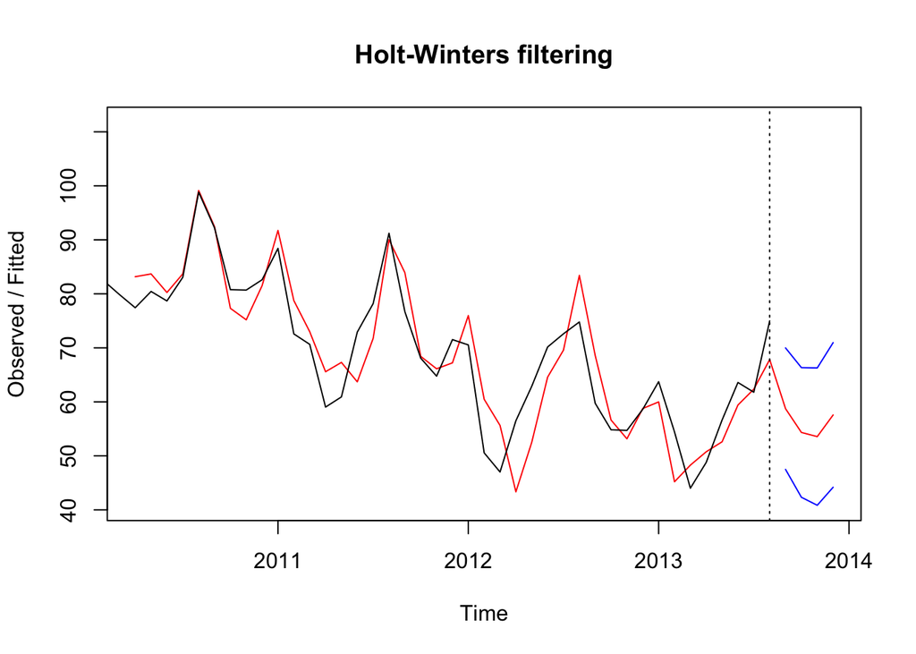

```r
plot(hw_T_S, predhw_T_S)
```

## HoltWinters model with defaults

```r
hw = HoltWinters(train_TS)
hw
```

```
## Holt-Winters exponential smoothing with trend and additive seasonal component.
##
## Call:
## HoltWinters(x = train_TS)
##
## Smoothing parameters:
##  alpha: 0.3727269
##  beta : 0
##  gamma: 0.9621566
##
## Coefficients:
##            [,1]
## a    59.0621049
## b    -0.7574812
## s1    0.4333145
## s2   -3.2103581
## s3   -3.2258040
## s4    1.5402385
## s5    5.9109799
## s6   -6.2013614
## s7  -13.9490602
## s8   -7.7330547
## s9   -0.7721952
## s10   5.3719761
## s11   4.6497546
## s12  15.7588265
```

```r
head(train_TS)
```

```
##            Apr       May       Jun       Jul       Aug       Sep
## 2009  89.33187  98.98226 111.71333 109.58000  99.34645  88.61500
```

```r
head(hw$fitted)
```

```
##              xhat    level      trend     season
## Apr 2010 83.16992 90.99995 -0.7574812 -7.0725445
## May 2010 83.68800 88.10218 -0.7574812 -3.6566946
## Jun 2010 80.24435 86.13468 -0.7574812 -5.1328446
## Jul 2010 83.70296 84.79549 -0.7574812 -0.3350463
## Aug 2010 99.14155 83.80004 -0.7574812 16.0989949
## Sep 2010 92.44193 82.92698 -0.7574812 10.2724392
```

```r
predhw = predict(hw, 4, prediction.interval = TRUE)
head(predhw)
```

```
##               fit      upr      lwr
## Sep 2013 58.73794 69.98481 47.49107
## Oct 2013 54.33678 66.33950 42.33407
## Nov 2013 53.56386 66.27755 40.85016
## Dec 2013 57.57242 70.95939 44.18545
```

### Find error for hw on both Test and Train data

```r
regr.eval(train$MeanPrice[13:length(train$MeanPrice)], hw$fitted[,1])
```

```
##         mae         mse        rmse        mape
##  4.60674466 32.12834186  5.66818682  0.07209383
```

```r
regr.eval(test$MeanPrice, predhw[,1])
```

```
##        mae        mse       rmse       mape
##  8.0086879 76.4706369  8.7447491  0.1631935
```

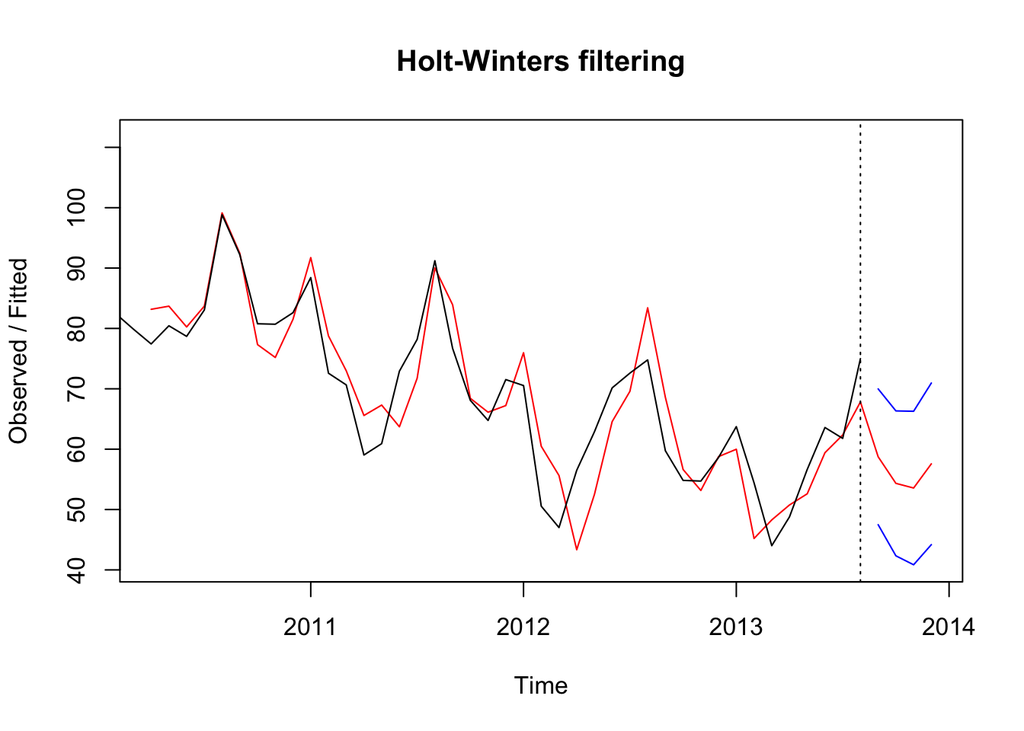

```r
plot(hw, predhw)
```

### ACF, PACF plots

- ACF: n th lag of ACF is the correlation between a day and n days before that.
- PACF: The same as ACF with all intermediate correlations removed.

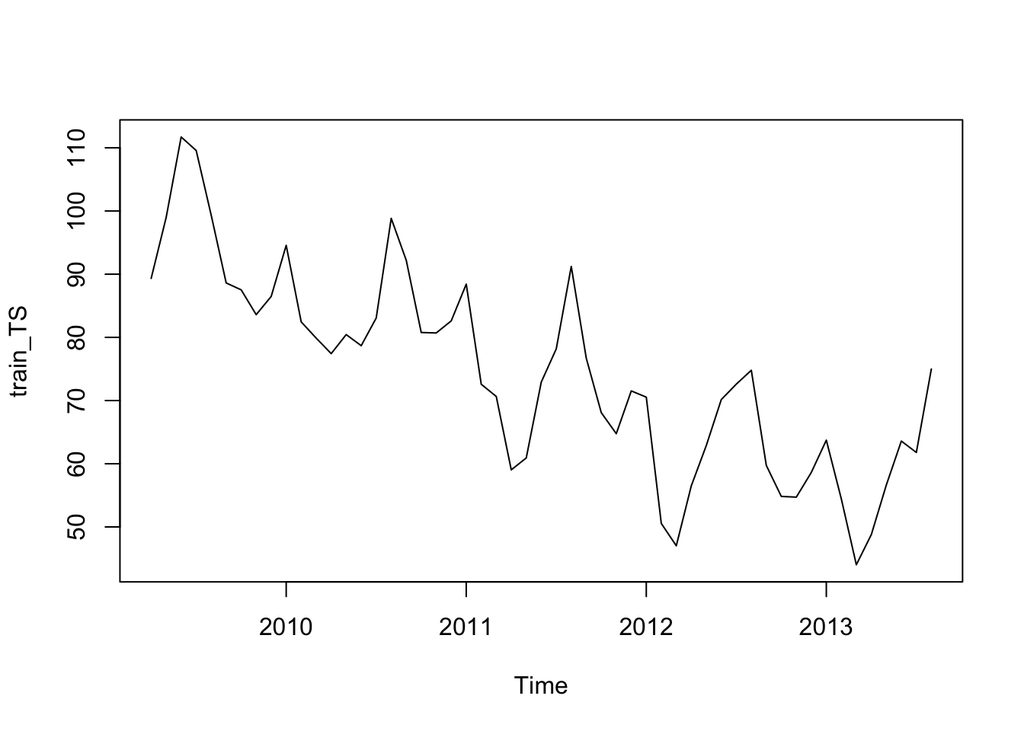

```r
par(mfrow=c(1,1))
plot(train_TS, type="l")
```

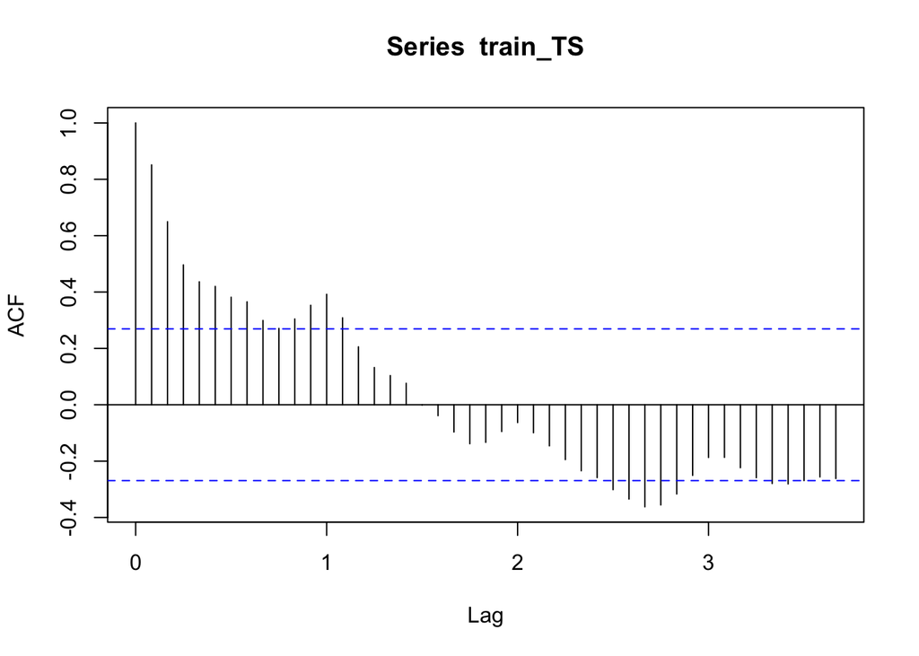

```r
acf(train_TS, lag=44)
```

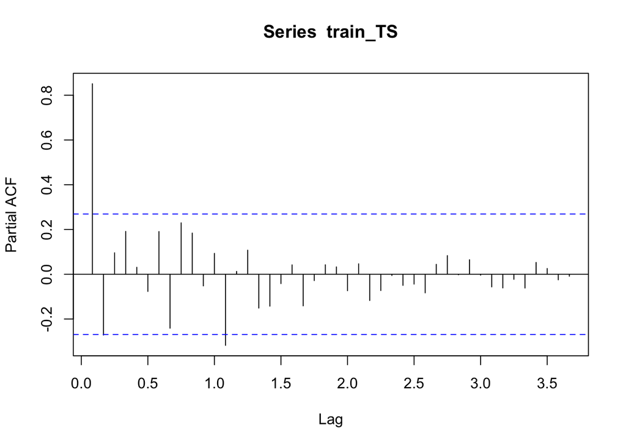

```r
pacf(train_TS, lag=44)
```

- ACF and PACF –> Idealized Trend, Seasonality and Randomness
  - Ideal Trend : Decreasing ACF and 1 or 2 lags of PACF
  - Ideal Seasonality: Cyclicality in ACF and a few lags of PACF with some positive and some negative
  - Ideal Random : A spike may or may not be present; even if present, magnitude will be small

### Let’s see the acf and pacf for one diff data.

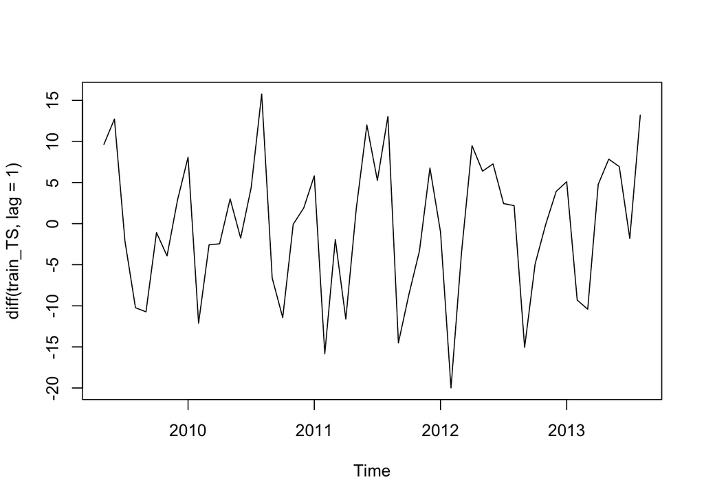

```r
par(mfrow=c(1,1))

plot(diff(train_TS, lag=1), type="l")
```

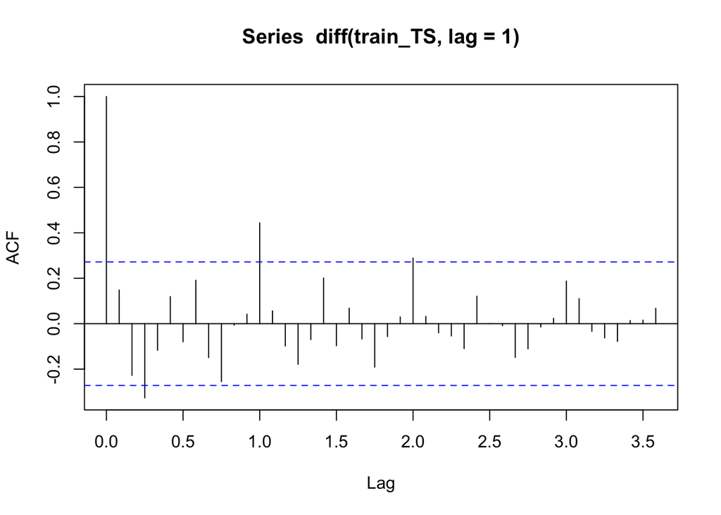

```r
acf(diff(train_TS,lag=1), lag=43)
```

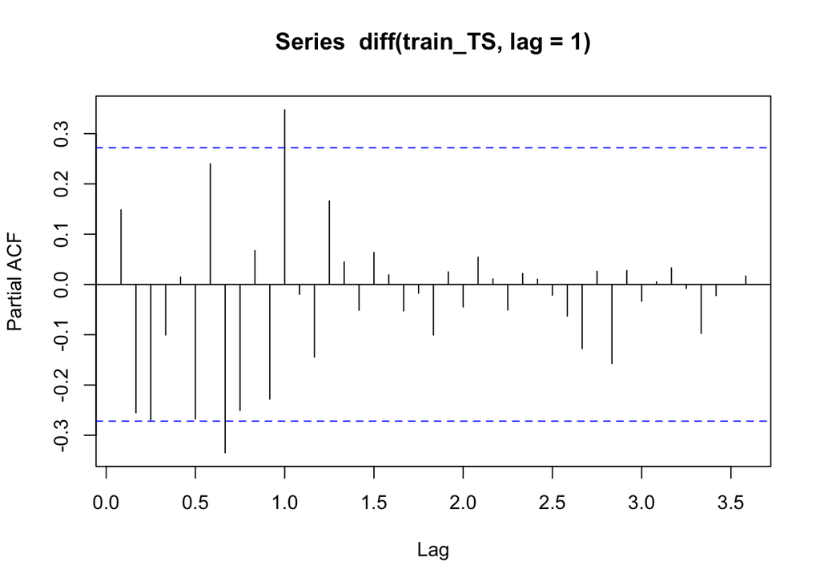

```r
pacf(diff(train_TS, lag=1),lag=43)
```

### Let’s see the acf and pacf for seasonal diff data.

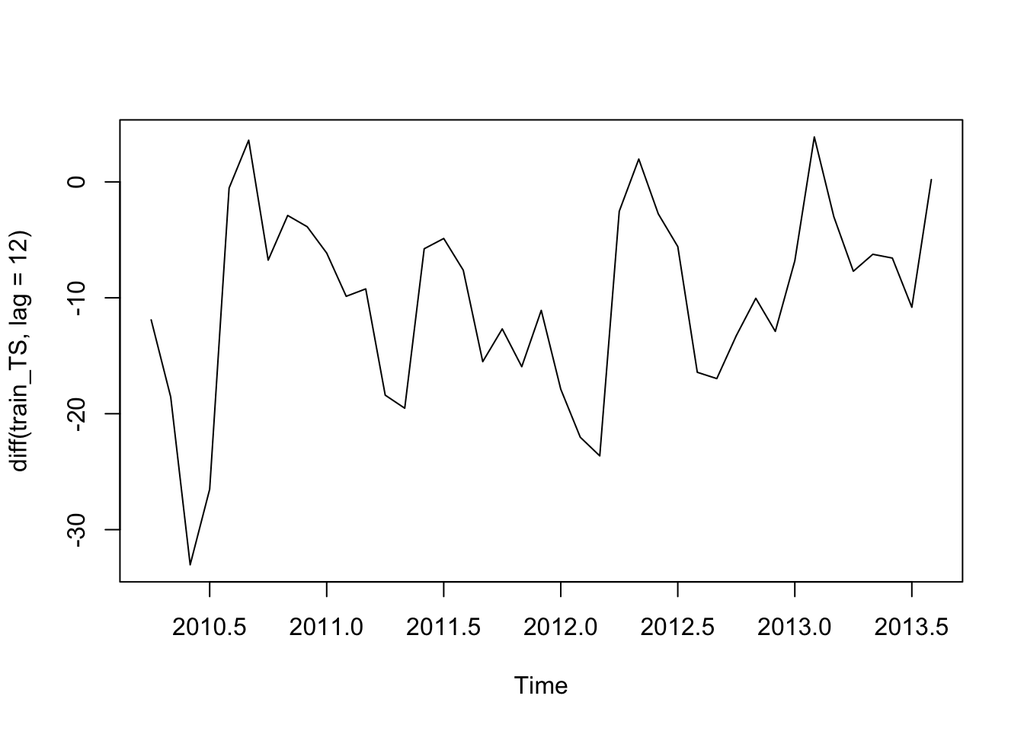

```r
par(mfrow=c(1,1))

plot(diff(train_TS, lag=12), type="l")
```

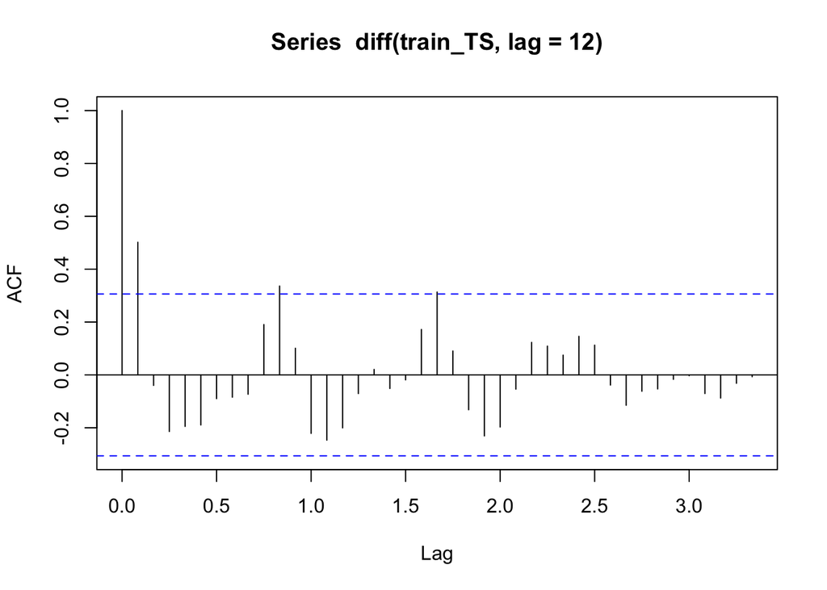

```r
acf(diff(train_TS,lag=12), lag=43)
```

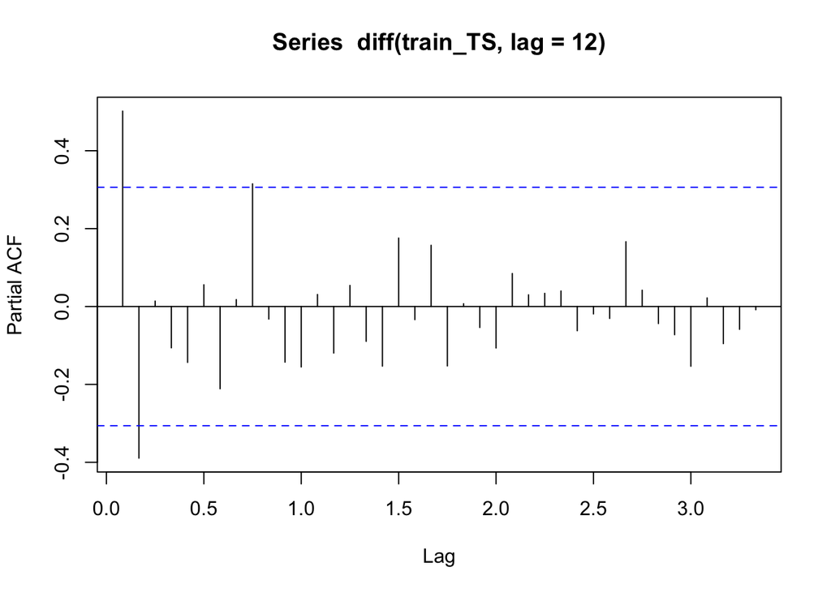

```r
pacf(diff(train_TS, lag=12),lag=43)
```

### Stationarize by differencing

- ndiffs and nsdiffs functions of forecast package can be used to findout the number of differences and seasonal differences, required to stationarize the data

```r
ndiffs(train_TS)
```

```
## [1] 1
```

```r
nsdiffs(train_TS)
```

```
## [1] 1
```

```r
ndiffs(diff(train_TS,lag=12))
```

```
## [1] 0
```